# Modelos Lineares Generalizados para Seguros de Automóvel

## Introdução

A precificação de seguros é um processo complexo que envolve a análise de diversos fatores para determinar o valor adequado das apólices, equilibrando o risco para a seguradora e a acessibilidade para os segurados. Nesse cenário, os Modelos Lineares Generalizados (GLMs, do inglês Generalized Linear Models) surgem como uma abordagem estatística fundamental. Eles são utilizados amplamente na indústria de seguros devido à sua capacidade de lidar com uma variedade de dados, lidar com distribuições não-normais e incorporar diferentes tipos de relação entre variáveis independentes e dependentes, além de ser facilmente interpretaveis.

# Generalized Linear Models for Auto Insurance

## Introduction

Insurance pricing is a complex process involving the analysis of various factors to determine the appropriate value of policies, balancing risk for the insurer and affordability for policyholders. In this context, Generalized Linear Models (GLMs) emerge as a fundamental statistical approach. They are widely utilized in the insurance industry due to their ability to handle a variety of data types, accommodate non-normal distributions, and incorporate different types of relationships between independent and dependent variables, all while being easily interpretable.

## Objetivo

Este estudo foi elaborado com base no livro “Generalized Linear Models for Insurance Rating”, como parte da disciplina de Tarifação de Seguros. Seu objetivo é realizar previsões para a severidade (custo médio de sinistros), a frequência de sinistros, utilizando dados referentes ao veículo Palio 1.0 no ano de 2020. O foco é explorar múltiplos modelos de Modelos Lineares Generalizados (MLGs) para identificar aquele que melhor se adapte aos dados e aos objetivos do estudo.

## Metodologia

Os dados empregados neste procedimento foram coletados diretamente do site da SUSEP[[1](http://www2.susep.gov.br/menuestatistica/Autoseg/principal.aspx)]. Eles consistem em estatísticas referentes a seguros de automóveis, enviadas semestralmente por companhias de seguros do Brasil. A base de dados contém informações abrangentes, incluindo exposição, prêmio médio, valor segurado médio, número de sinistros e valor de indenizações. Essas informações são categorizadas de acordo com o modelo e ano do veículo, a região geográfica e os CEPs correspondentes.

Neste estudo, nossa análise se concentrará nos dados do modelo de carro Palio 1.0 no ano de 2020, na região sudeste do Brasil (abrangendo São Paulo, Minas Gerais, Espírito Santo e Rio de Janeiro). Estes dados serão agrupados com base em faixas etárias e sexo, abrangendo variáveis como exposição, prêmio médio, frequência de sinistros, severidade e indenização total.

## Análise

Ultilizadndo o pacote `dplyr` para agregar os dados de freqûencia indenização e regiões, além de tratar as demais variaveis do dataset e imprimir em formato de tabela com o pacote `gt`.

```r
dados = read.csv('~/UFMG/2023.1/TARIFACAO SEGUROS/trabalho final - Copia/dados_palio_1_0.csv',
                 sep = ';')

# ETL DO DATASET
dados_mod = dados %>%
  mutate(FREQ_TOTAL = FREQ_COLISAO+FREQ_INCENDIO_ROUBO+FREQ_OUTRAS,
         INDENIZACAO_TOTAL_TOTAL = INDENI_INCENDIO_ROUBO+INDENI_COLI+INDEN_OUTRAS,
         UF = substr(REGIAO, start=1, stop=2),
         FAIXA_ETARIA = substr(FAIXA_ETARIA, start=7, stop=length(FAIXA_ETARIA)),
         FAIXA_ETARIA = if_else(FAIXA_ETARIA == 'que 55 anos', '55 ou mais',FAIXA_ETARIA),
         CUSTO_MEDIO = INDENIZACAO_TOTAL_TOTAL / FREQ_TOTAL) %>%
  dplyr::select(UF,
         SEXO_CONDUTOR,
         FAIXA_ETARIA,
         EXPOSTOS,
         PREMIO_MEDIO,
         FREQ_TOTAL,
         INDENIZACAO_TOTAL_TOTAL,
         CUSTO_MEDIO) %>%
  arrange(sample(n())) ### aleatorizar

#### imprimir em tabela
gt(head(dados_mod))
```

| UF | SEXO_CONDUTOR | FAIXA_ETARIA | EXPOSTOS | PREMIO_MEDIO | FREQ_TOTAL | INDENIZACAO_TOTAL_TOTAL | CUSTO_MEDIO |
| --- | --- | --- | --- | --- | --- | --- | --- |
| SP | Masculino | 46 e 55 anos | 2454 | 733 | 598 | 938072 | 1568.682 |
| MG | Feminino | 46 e 55 anos | 199 | 742 | 47 | 95930 | 2041.064 |
| MG | Masculino | 18 e 25 anos | 231 | 1157 | 61 | 272472 | 4466.754 |
| MG | Masculino | 36 e 45 anos | 536 | 855 | 203 | 481430 | 2371.576 |
| MG | Feminino | 18 e 25 anos | 103 | 1025 | 17 | 37102 | 2182.471 |
| MG | Feminino | 26 e 35 anos | 139 | 838 | 46 | 67951 | 1477.196 |

### Modelos para a Frequência de Sinistros.

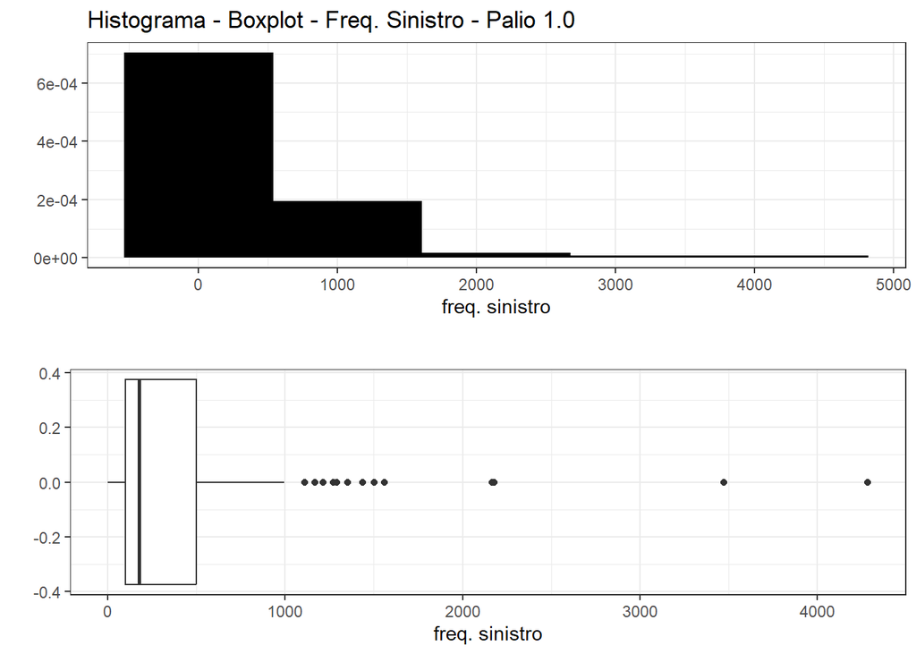

Esta distribuição guarda semelhanças marcantes com modelos GLM Binomial Negativo (que envolvem o número de tentativas necessárias para alcançar o sucesso), Poisson (usado para contagem ou taxa de eventos raros visando um sucesso) e Quase-Poisson (empregado quando a média difere da variância). No contexto presente, observaremos que o modelo Poisson não se adequará de forma ótima, precisamente devido à presença de dados com sobre-dispersão, onde a variância de 4.2737976^{5} é maior que a média de 432.83.

##### *Separando em Treino e Teste*

Para validar os dados, tanto a fonte primária deste estudo quanto os princípios da Ciência de Dados recomendam a divisão dos dados em conjuntos de treinamento e teste, esta separação ocorrerá com as variaveis estratificada, pois estamos lidando com dados agrupados. Isso permite avaliar a aderência do modelo, que desempenhará o papel de um multiplicador determinante para estimar a ocorrência de Sinistros para os grupos estabelecidos, isso de fato é o que importará para as seguradoras.

```r
ir <- dados_mod[c('FREQ_TOTAL','UF','FAIXA_ETARIA','EXPOSTOS')]
y <- multi_strata(ir, k = 5)
inds <- partition(
  y, p = c(train = 0.75,  test = 0.25), split_into_list = FALSE
) # 75% para treino e 25% para teste
dados_mod$TREIN_TEST = inds
dados_treino = dados_mod[dados_mod$TREIN_TEST == 'train',]
dados_teste =  dados_mod[dados_mod$TREIN_TEST == 'test',]
```

Para aprimorar a seleção das variáveis explicativas que serão incluídas em nosso modelo, empregamos um método denominado de `Stepwise`. Nesse contexto, utilizamos o critério conhecido como “AIC” (Critério de Informação de Akaike, em inglês Akaike Information Criterion), o qual compara o AIC mínimo em relação ao modelo nulo.

Em termos práticos, esse procedimento visa obter um modelo que apresente variáveis preditoras mais eficazes na explicação da frequência de sinistros em comparação com um modelo desprovido de quaisquer variáveis. Em outras palavras, buscamos construir um modelo que seja substancialmente melhor em explicar a ocorrência de sinistros por meio da inclusão das variáveis selecionadas.

##### Binomial Negativo

```r
### BINOMIAL NEGATICO COM PESSOS (de acordo com o livro indicado) ------------------
null.nb1 <- glm.nb(FREQ_TOTAL ~ 1, weights = EXPOSTOS,data = dados_treino)
sm.nb1 <- step(null.nb1, direction = "both", scope = ~ UF + SEXO_CONDUTOR + FAIXA_ETARIA  )

### BINOMIAL NEGATICO SEM PESSOS -------------------
null.nb2 <- glm.nb(FREQ_TOTAL ~ 1, EXPOSTOS,data = dados_treino)
sm.nb2 <- step(null.nb2, direction = "both", scope = ~ UF +  EXPOSTOS + SEXO_CONDUTOR + FAIXA_ETARIA  )
```

Estimativas e P-valor - Binomial Negativo com pesos

| Xij | Estimates | P_valor |
| --- | --- | --- |
| (Intercept) | 2.80 | 0 |
| UFMG | 1.27 | 0 |
| UFRJ | 1.13 | 0 |
| UFSP | 2.36 | 0 |
| FAIXA_ETARIA26 e 35 anos | 1.93 | 0 |
| FAIXA_ETARIA36 e 45 anos | 2.16 | 0 |
| FAIXA_ETARIA46 e 55 anos | 1.82 | 0 |
| FAIXA_ETARIA55 ou mais | 2.69 | 0 |
| SEXO_CONDUTORMasculino | -0.14 | 0 |

Estimativas e P-valor - Binomial Negativo sem pesos

| Xij | Estimates | P_valor |
| --- | --- | --- |
| (Intercept) | 3.86 | 0 |
| EXPOSTOS | 0.00 | 0 |
| UFMG | 0.47 | 0 |
| UFRJ | 0.97 | 0 |
| UFSP | 0.93 | 0 |
| FAIXA_ETARIA26 e 35 anos | 0.88 | 0 |
| FAIXA_ETARIA36 e 45 anos | 0.83 | 0 |
| FAIXA_ETARIA46 e 55 anos | 0.75 | 0 |
| FAIXA_ETARIA55 ou mais | 0.74 | 0 |
| SEXO_CONDUTORMasculino | -0.19 | 0 |

Com base nos resultados, observamos que todas as variáveis explicativas apresentaram significância estatística, conforme indicado pelo p-valor de nível de 1%. Além disso, é interessante notar que o processo de seleção de variáveis usando o método stepwise incorporou todas as variáveis disponíveis em nosso modelo. Essa inclusão ampla pode indicar a influência substancial de cada uma dessas variáveis no resultado, considerando a alta confiança estatística proporcionada pelo nível de significância escolhido.

A seguir, apresento um gráfico de envelope que avalia a qualidade do ajuste de cada modelo. Isso é realizado por meio de simulações utilizando os parâmetros estimados das distribuições selecionadas:

```r
par(mfrow = c(1,2))
hnp(sm.nb1, type.resid = "deviance", how.many.out = TRUE, paint.out = TRUE,sim = n_simulacoes)
```

```
## Negative binomial model (using MASS package)
```

```
## Total points: 82
## Points out of envelope: 51 ( 62.2 %)
```

```r
hnp(sm.nb2, type.resid = "deviance", how.many.out = TRUE, paint.out = TRUE,sim = n_simulacoes)
```

```
## Negative binomial model (using MASS package)
```

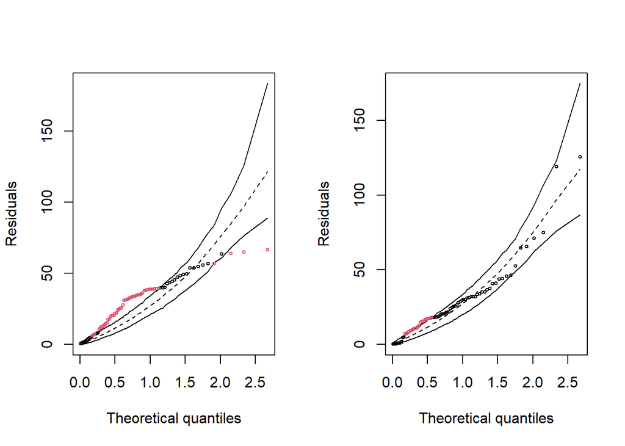

```
## Total points: 82
## Points out of envelope: 24 ( 29.27 %)
```

Aqui vemos um melhor ajuste no modelo binomial negativo sem a ultilização do peso, ficaremos com este modelo.

##### Poisson e Quasi-Poisson

```r
# POISSON --------------
null.p <- glm(FREQ_TOTAL ~ 1, offset = log(EXPOSTOS) ,data = dados_treino,
              family = poisson )
sm.p <- step(null.p, direction = "both", scope = ~ UF + SEXO_CONDUTOR + FAIXA_ETARIA  )

# QUASI-POISSON ----------
mod.qp <- glm(FREQ_TOTAL ~ UF + SEXO_CONDUTOR + FAIXA_ETARIA , offset(log(EXPOSTOS)),
               data = dados_treino, family = quasipoisson)
```

Estimativas e P-valor - Poisson

| Xij | Estimates | P_valor |
| --- | --- | --- |
| (Intercept) | -1.33 | 0.00000 |
| UFMG | -0.07 | 0.04070 |
| UFRJ | 0.37 | 0.00000 |
| UFSP | 0.46 | 0.00000 |
| FAIXA_ETARIA26 e 35 anos | 0.09 | 0.00788 |
| FAIXA_ETARIA36 e 45 anos | 0.10 | 0.00605 |
| FAIXA_ETARIA46 e 55 anos | -0.05 | 0.18341 |
| FAIXA_ETARIA55 ou mais | 0.24 | 0.00000 |
| SEXO_CONDUTORMasculino | -0.15 | 0.00000 |

Estimativas e P-valor - Quasi-Poisson

| Xij | Estimates | P_valor |
| --- | --- | --- |
| (Intercept) | 2.77 | 0.00440 |
| UFMG | 0.82 | 0.24206 |
| UFRJ | 0.93 | 0.20472 |
| UFSP | 2.02 | 0.00344 |
| SEXO_CONDUTORMasculino | -0.10 | 0.60303 |
| FAIXA_ETARIA26 e 35 anos | 1.86 | 0.01133 |
| FAIXA_ETARIA36 e 45 anos | 2.12 | 0.00363 |
| FAIXA_ETARIA46 e 55 anos | 1.78 | 0.01555 |
| FAIXA_ETARIA55 ou mais | 2.73 | 0.00017 |

Neste vemos a precença de algumas variaveis, que, a um nivel de significaqncia de 1% não apresentan significancia.

```r
par(mfrow = c(1,2))
hnp(sm.p, type.resid = "deviance", how.many.out = TRUE, paint.out = TRUE,sim = n_simulacoes)
```

```
## Poisson model
```

```
## Total points: 82
## Points out of envelope: 80 ( 97.56 %)
```

```r
hnp(mod.qp, type.resid = "deviance", how.many.out = TRUE, paint.out = TRUE,sim = n_simulacoes)
```

```
## Quasi-Poisson model
```

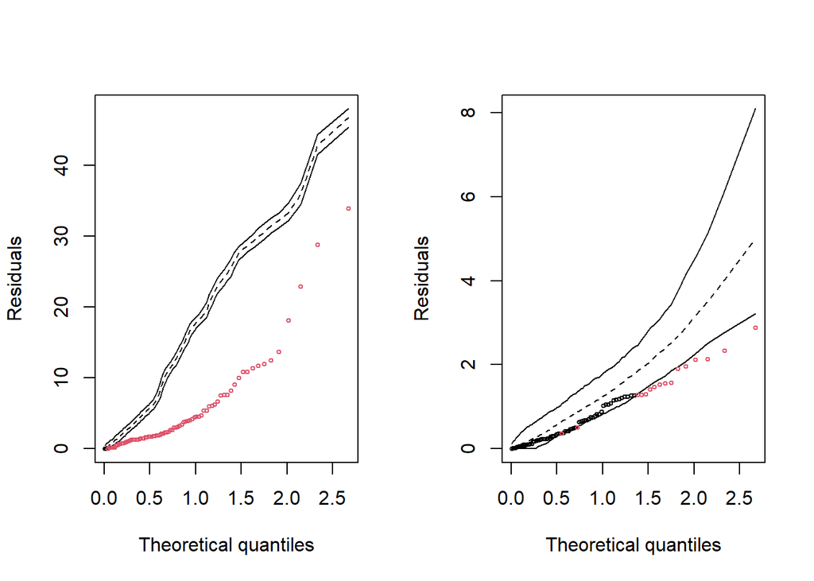

```
## Total points: 82
## Points out of envelope: 16 ( 19.51 %)
```

Em comparação com o modelo Poisson, observamos um desempenho superior no caso do modelo Quasi-Poisson. Em relação ao Binomial Negativo sem considerar os pesos, notamos que, embora haja menos observações fora do intervalo esperado, os pontos apresentam uma dispersão significativamente maior em relação ao limiar. Embora a avaliação dos dados de teste seja necessária para uma conclusão definitiva, há indicações visuais substanciais de que o *modelo binomial negativo* possa apresentar o desempenho mais robusto.

### Modelos para Severidade

Com o objetivo de otimizar o espaço e a apresentação visual do documento, omitiremos os passos relativos à separação entre treino e teste e repetiremos os procedimentos passo a passo para a construção do modelo de severidade (custo médio).

Os gráficos abaixo mostram exatamente este caso:

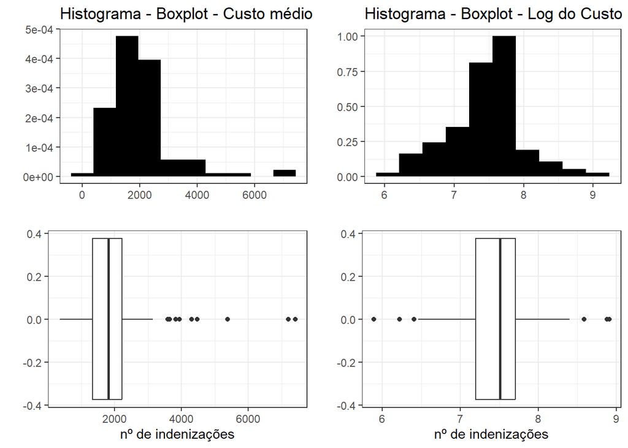

```r
## GAMMA
null.gamma <- glm(CUSTO_MEDIO ~ 1 ,  weights = log(EXPOSTOS), family = Gamma(link = "log"),data = dados_treino)
sm.gamma <- step(null.gamma, direction = "both", scope = ~  UF + SEXO_CONDUTOR + FAIXA_ETARIA )

#### LOG NORMAL
null.normal <- glm(CUSTO_MEDIO ~ 1 , family =  gaussian(link = "identity"),data = dados_treino, weights = EXPOSTOS)
sm.normal <- step(null.normal, direction = "both", scope = ~  UF + SEXO_CONDUTOR + FAIXA_ETARIA )
```

Estimativas e P-valor - Gamma

| Xij | Estimates | P_valor |
| --- | --- | --- |
| (Intercept) | 7.86 | 0.00000 |
| UFMG | 0.24 | 0.13695 |
| UFRJ | -0.17 | 0.37500 |
| UFSP | -0.31 | 0.05468 |
| FAIXA_ETARIA26 e 35 anos | -0.31 | 0.03438 |
| FAIXA_ETARIA36 e 45 anos | -0.34 | 0.02179 |
| FAIXA_ETARIA46 e 55 anos | -0.48 | 0.00202 |
| FAIXA_ETARIA55 ou mais | -0.70 | 0.00001 |
| SEXO_CONDUTORMasculino | 0.20 | 0.02147 |

Estimativas e P-valor - Gaussiano

| Xij | Estimates | P_valor |
| --- | --- | --- |
| (Intercept) | 2837.03 | 0.00000 |
| UFMG | 146.36 | 0.60145 |
| UFRJ | -546.43 | 0.09472 |
| UFSP | -689.32 | 0.01279 |
| FAIXA_ETARIA26 e 35 anos | -576.12 | 0.06464 |
| FAIXA_ETARIA36 e 45 anos | -735.57 | 0.01692 |
| FAIXA_ETARIA46 e 55 anos | -987.44 | 0.00235 |
| FAIXA_ETARIA55 ou mais | -1407.11 | 0.00001 |
| SEXO_CONDUTORMasculino | 361.10 | 0.00052 |

Inicialmente, é importante destacar que as variáveis de maior significância encontram-se incorporadas no modelo gaussiano. Posteriormente, verificaremos a aderência superior do modelo gaussiano, conforme evidenciado no gráfico de envelope abaixo.

```r
par(mfrow = c(1,2))
hnp(sm.gamma, type.resid = "deviance", how.many.out = TRUE, paint.out = TRUE,sim = n_simulacoes)
```

```
## Gamma model
```

```
## Total points: 83
## Points out of envelope: 12 ( 14.46 %)
```

```r
hnp(sm.normal, type.resid = "deviance", how.many.out = TRUE, paint.out = TRUE,sim = n_simulacoes)
```

```
## Gaussian model (glm object)
```

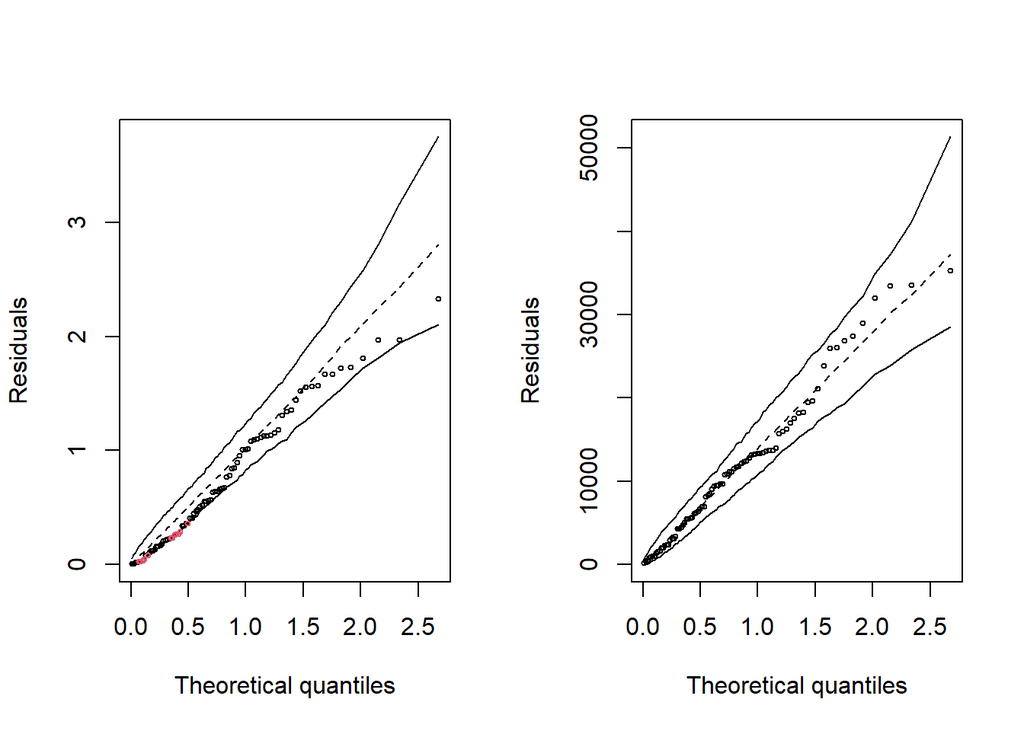

```
## Total points: 83
## Points out of envelope: 0 ( 0 %)
```

## Validando os dados

A seguir, pegaremos nossos dados de teste para validação dos nossos modelos escolhidos, temos a seguinte relação:

[output not shown]

### Modelo Binomial Negativo para estimar a Frequência

```
## # A tibble: 7 × 4
## # Groups:   UF [4]
##   UF    SEXO_CONDUTOR FREQUENCIA_PREDICT FREQUENCIA_OBS
##   <chr> <chr>                      <dbl>          <dbl>
## 1 ES    Masculino                   117.           165
## 2 MG    Feminino                    302.           347.
## 3 MG    Masculino                   244.           258.
## 4 RJ    Feminino                    356.           292.
## 5 RJ    Masculino                   388.           381.
## 6 SP    Feminino                    592.           850
## 7 SP    Masculino                   660.           710
```

### Modelo Quasi-Poisson para estimar a Frequência

```
## # A tibble: 7 × 4
## # Groups:   UF [4]
##   UF    SEXO_CONDUTOR FREQUENCIA_PREDICT FREQUENCIA_OBS
##   <chr> <chr>                      <dbl>          <dbl>
## 1 ES    Masculino                   221.           165
## 2 MG    Feminino                    269.           347.
## 3 MG    Masculino                   364.           258.
## 4 RJ    Feminino                    212.           292.
## 5 RJ    Masculino                   267.           381.
## 6 SP    Feminino                    617.           850
## 7 SP    Masculino                  1089.           710
```

### Modelo Poisson para estimar a Frequência

```
## # A tibble: 7 × 4
## # Groups:   UF [4]
##   UF    SEXO_CONDUTOR FREQUENCIA_PREDICT FREQUENCIA_OBS
##   <chr> <chr>                      <dbl>          <dbl>
## 1 ES    Masculino                   213.           165
## 2 MG    Feminino                    332.           347.
## 3 MG    Masculino                   244.           258.
## 4 RJ    Feminino                    279.           292.
## 5 RJ    Masculino                   406.           381.
## 6 SP    Feminino                    638.           850
## 7 SP    Masculino                   875.           710
```

### Modelo Gaussiano para estimar a Severidade

```
## # A tibble: 7 × 4
## # Groups:   UF [4]
##   UF    SEXO_CONDUTOR SEVERIDADE_PREDICT SEVERIDADE_OBISERVADA
##   <chr> <chr>                      <dbl>                 <dbl>
## 1 ES    Feminino                   2055.                 1939.
## 2 MG    Feminino                   2326.                 1828.
## 3 MG    Masculino                  2457.                 1919.
## 4 RJ    Feminino                   1434.                 1460.
## 5 RJ    Masculino                  1932.                 1756.
## 6 SP    Feminino                   1160.                  919.
## 7 SP    Masculino                  1915.                 2086.
```

### Modelo Gamma para estimar a Severidade

```
## # A tibble: 7 × 4
## # Groups:   UF [4]
##   UF    SEXO_CONDUTOR SEVERIDADE_PREDICT SEVERIDADE_OBISERVADA
##   <chr> <chr>                      <dbl>                 <dbl>
## 1 ES    Feminino                   1757.                 1939.
## 2 MG    Feminino                   2438.                 1828.
## 3 MG    Masculino                  2745.                 1919.
## 4 RJ    Feminino                   1449.                 1460.
## 5 RJ    Masculino                  1971.                 1756.
## 6 SP    Feminino                   1183.                  919.
## 7 SP    Masculino                  1801.                 2086.
```

## Conclusão

Em resumo, conseguimos obter indicadores positivos em relação à severidade e frequência de ocorrências de sinistros para eventos futuros envolvendo este modelo de carro.

Uma vez que utilizamos dados do ano de 2020, visando potencialmente aplicá-los nos anos subsequentes, seria benéfico mantermos a análise atualizada de forma contínua. Isso poderia ser realizado através da inclusão dos dados do próximo ano ou através da criação de intervalos de um ou dois anos, buscando assim aprimorar a precisão das projeções.

Se houver a necessidade de aprimorar os modelos utilizados, existe a possibilidade de desenvolvermos nossas próprias distribuições personalizadas. No entanto, considerando que o foco principal deste estudo era a aplicação de distribuições amplamente reconhecidas, surge a provocação para explorar a utilização de outras distribuições em futuras pesquisas.

## Referências

Autoseg. Disponível em: http://www2.susep.gov.br/menuestatistica/Autoseg/principal.aspx. Acesso em: 21 ago. 2023.

GOLDBURD, M.; KHARE, A.; TEVET, D. Generalized Linear Models for Insurance Rating. [s.l: s.n.]. em: https://www.casact.org/sites/default/files/2021-01/05-Goldburd-Khare-Tevet.pdf